# Mixed models 2

## Year as fixed or random effect?

```
## [1] 217
```

```
##
## 1991 1993 1994 1995 1996 1997 1998 1999 2000 2001 2002 2003 2004 2005 2006 2007
##    1    1    4    3    3    5    5    5    7    7    8    6    8    7   10    9
## 2008 2009 2010 2011 2012 2013 2014 2015 2016 2017 2018 2019 2020
##   10   10   10    9   10    9   10   10   10   10   10   10   10
```

Year as a fixed effect models a linear change in the response with years. This does not correct for the non-independence between data collected on a given year.

```r
summary(lm(babies ~ 1 + year, data = data))
```

```
##
## Call:
## lm(formula = babies ~ 1 + year, data = data)
##
## Residuals:
##     Min      1Q  Median      3Q     Max
## -4.6103 -1.4083 -0.1328  1.1969  5.3491
##
## Coefficients:
##              Estimate Std. Error t value Pr(>|t|)
## (Intercept) 986.31562   34.83814  28.311  < 2e-16 ***
## year          0.10678    0.01734   6.158 3.58e-09 ***
## ---
## Signif. codes:  0 '***' 0.001 '**' 0.01 '*' 0.05 '.' 0.1 ' ' 1
##
## Residual standard error: 1.86 on 215 degrees of freedom
## Multiple R-squared:  0.1499, Adjusted R-squared:  0.146
## F-statistic: 37.92 on 1 and 215 DF,  p-value: 3.579e-09
```

```r
summary(lm(babies ~ 1 + storks, data = data))
```

```
##
## Call:
## lm(formula = babies ~ 1 + storks, data = data)
##
## Residuals:
##     Min      1Q  Median      3Q     Max
## -5.0552 -1.3745 -0.0409  1.1854  4.7969
##
## Coefficients:
##              Estimate Std. Error  t value Pr(>|t|)
## (Intercept) 1.200e+03  1.612e-01 7445.831  < 2e-16 ***
## storks      4.066e-03  1.007e-03    4.037 7.53e-05 ***
## ---
## Signif. codes:  0 '***' 0.001 '**' 0.01 '*' 0.05 '.' 0.1 ' ' 1
##
## Residual standard error: 1.945 on 215 degrees of freedom
## Multiple R-squared:  0.07046,    Adjusted R-squared:  0.06614
## F-statistic:  16.3 on 1 and 215 DF,  p-value: 7.526e-05
```

```r
summary(lm(babies ~ 1 + storks +  year, data = data))
```

```
##
## Call:
## lm(formula = babies ~ 1 + storks + year, data = data)
##
## Residuals:
##     Min      1Q  Median      3Q     Max
## -4.6607 -1.4066 -0.1324  1.1480  5.4436
##
## Coefficients:
##               Estimate Std. Error t value Pr(>|t|)
## (Intercept)  9.618e+02  5.282e+01  18.208  < 2e-16 ***
## storks      -9.056e-04  1.463e-03  -0.619    0.537
## year         1.190e-01  2.634e-02   4.519 1.03e-05 ***
## ---
## Signif. codes:  0 '***' 0.001 '**' 0.01 '*' 0.05 '.' 0.1 ' ' 1
##
## Residual standard error: 1.863 on 214 degrees of freedom
## Multiple R-squared:  0.1514, Adjusted R-squared:  0.1435
## F-statistic:  19.1 on 2 and 214 DF,  p-value: 2.341e-08
```

Year as a random effect models differences among years, without considering that years come in a specific order. The random effect correct the estimation of the fixed effect for non-independence between data collected on a give year. However, the random effect does not correct for linear changes in other fixed effects with time.

```r
summary(lmer(babies ~ 1 + (1|year), data = data))
```

```
## Linear mixed model fit by REML. t-tests use Satterthwaite's method [
## lmerModLmerTest]
## Formula: babies ~ 1 + (1 | year)
##    Data: data
##
## REML criterion at convergence: 850.9
##
## Scaled residuals:
##      Min       1Q   Median       3Q      Max
## -2.40554 -0.61816 -0.05888  0.64060  3.08569
##
## Random effects:
##  Groups   Name        Variance Std.Dev.
##  year     (Intercept) 1.942    1.394
##  Residual             2.293    1.514
## Number of obs: 217, groups:  year, 29
##
## Fixed effects:
##             Estimate Std. Error       df t value Pr(>|t|)
## (Intercept) 1200.631      0.284   26.870    4228   <2e-16 ***
## ---
## Signif. codes:  0 '***' 0.001 '**' 0.01 '*' 0.05 '.' 0.1 ' ' 1
```

```r
summary(lmer(babies ~ 1 + storks + (1|year), data = data))
```

```
## Linear mixed model fit by REML. t-tests use Satterthwaite's method [
## lmerModLmerTest]
## Formula: babies ~ 1 + storks + (1 | year)
##    Data: data
##
## REML criterion at convergence: 857.2
##
## Scaled residuals:
##     Min      1Q  Median      3Q     Max
## -2.4089 -0.6134 -0.1086  0.6304  2.8922
##
## Random effects:
##  Groups   Name        Variance Std.Dev.
##  year     (Intercept) 1.672    1.293
##  Residual             2.296    1.515
## Number of obs: 217, groups:  year, 29
##
## Fixed effects:
##              Estimate Std. Error        df t value Pr(>|t|)
## (Intercept) 1.200e+03  3.127e-01 2.748e+01 3838.79   <2e-16 ***
## storks      4.473e-03  2.140e-03 2.570e+01    2.09   0.0467 *
## ---
## Signif. codes:  0 '***' 0.001 '**' 0.01 '*' 0.05 '.' 0.1 ' ' 1
##
## Correlation of Fixed Effects:
##        (Intr)
## storks -0.522
```

Sometimes you need both. Year can be both a fixed and a random effect, meaning we want to model a linear change, and the dependence between data collected on the same years.

```r
summary(lmer(babies ~ 1 + storks +  year + (1|year) , data = data))
```

```
## Linear mixed model fit by REML. t-tests use Satterthwaite's method [
## lmerModLmerTest]
## Formula: babies ~ 1 + storks + year + (1 | year)
##    Data: data
##
## REML criterion at convergence: 856
##
## Scaled residuals:
##     Min      1Q  Median      3Q     Max
## -2.4804 -0.6266 -0.0410  0.6304  3.0011
##
## Random effects:
##  Groups   Name        Variance Std.Dev.
##  year     (Intercept) 1.351    1.162
##  Residual             2.296    1.515
## Number of obs: 217, groups:  year, 29
##
## Fixed effects:
##               Estimate Std. Error         df t value Pr(>|t|)
## (Intercept)  9.827e+02  8.868e+01  3.226e+01  11.081 1.56e-12 ***
## storks      -5.718e-04  2.843e-03  2.685e+01  -0.201   0.8421
## year         1.086e-01  4.426e-02  3.222e+01   2.454   0.0197 *
## ---
## Signif. codes:  0 '***' 0.001 '**' 0.01 '*' 0.05 '.' 0.1 ' ' 1
##
## Correlation of Fixed Effects:
##        (Intr) storks
## storks  0.723
## year   -1.000 -0.724
```

Try with the roo dataset:

```r
summary(lm(EscapeDistance ~ Tail_Length + Year , data = roo))
```

```
##
## Call:
## lm(formula = EscapeDistance ~ Tail_Length + Year, data = roo)
##
## Residuals:
##     Min      1Q  Median      3Q     Max
## -22.101  -4.024  -0.593   3.493  36.124
##
## Coefficients:
##               Estimate Std. Error t value Pr(>|t|)
## (Intercept) -1.389e+03  1.100e+02  -12.63   <2e-16 ***
## Tail_Length  1.086e+00  1.695e-02   64.09   <2e-16 ***
## Year         6.802e-01  5.467e-02   12.44   <2e-16 ***
## ---
## Signif. codes:  0 '***' 0.001 '**' 0.01 '*' 0.05 '.' 0.1 ' ' 1
##
## Residual standard error: 5.917 on 2453 degrees of freedom
## Multiple R-squared:  0.6269, Adjusted R-squared:  0.6266
## F-statistic:  2061 on 2 and 2453 DF,  p-value: < 2.2e-16
```

```r
summary(lmer(EscapeDistance ~Tail_Length + (1|Year), data = roo))
```

```
## Linear mixed model fit by REML. t-tests use Satterthwaite's method [
## lmerModLmerTest]
## Formula: EscapeDistance ~ Tail_Length + (1 | Year)
##    Data: roo
##
## REML criterion at convergence: 15630
##
## Scaled residuals:
##     Min      1Q  Median      3Q     Max
## -3.6300 -0.6676 -0.0983  0.5826  6.0700
##
## Random effects:
##  Groups   Name        Variance Std.Dev.
##  Year     (Intercept)  4.108   2.027
##  Residual             33.561   5.793
## Number of obs: 2456, groups:  Year, 8
##
## Fixed effects:
##               Estimate Std. Error         df t value Pr(>|t|)
## (Intercept)  -25.52373    1.18717   48.52328  -21.50   <2e-16 ***
## Tail_Length    1.14330    0.01763 2451.96379   64.85   <2e-16 ***
## ---
## Signif. codes:  0 '***' 0.001 '**' 0.01 '*' 0.05 '.' 0.1 ' ' 1
##
## Correlation of Fixed Effects:
##             (Intr)
## Tail_Length -0.789
```

```r
summary(lmer(EscapeDistance ~Tail_Length + Year + (1|Year), data = roo))
```

```
## Linear mixed model fit by REML. t-tests use Satterthwaite's method [
## lmerModLmerTest]
## Formula: EscapeDistance ~ Tail_Length + Year + (1 | Year)
##    Data: roo
##
## REML criterion at convergence: 15627.1
##
## Scaled residuals:
##     Min      1Q  Median      3Q     Max
## -3.6240 -0.6688 -0.0988  0.5875  6.0857
##
## Random effects:
##  Groups   Name        Variance Std.Dev.
##  Year     (Intercept)  2.68    1.637
##  Residual             33.56    5.793
## Number of obs: 2456, groups:  Year, 8
##
## Fixed effects:
##               Estimate Std. Error         df t value Pr(>|t|)
## (Intercept) -1.122e+03  5.206e+02  5.822e+00  -2.155   0.0760 .
## Tail_Length  1.142e+00  1.761e-02  2.436e+03  64.867   <2e-16 ***
## Year         5.456e-01  2.591e-01  5.822e+00   2.106   0.0812 .
## ---
## Signif. codes:  0 '***' 0.001 '**' 0.01 '*' 0.05 '.' 0.1 ' ' 1
##
## Correlation of Fixed Effects:
##             (Intr) Tl_Lng
## Tail_Length -0.011
## Year        -1.000  0.009
```

More than one parameter:

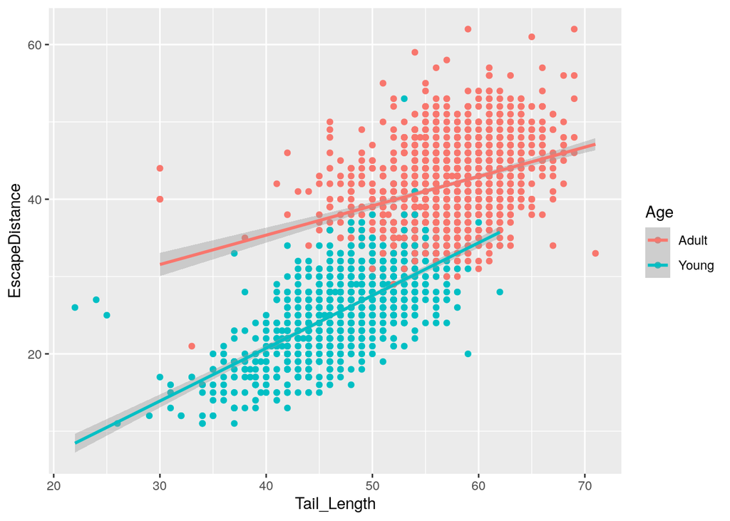

```r
ggplot(roo, aes(x=Tail_Length, y=EscapeDistance, color=Age)) +
  geom_point() + geom_smooth(method = "lm")
```

```r
summary(lm(EscapeDistance ~ Age*Sex, data = roo))
```

```
##
## Call:
## lm(formula = EscapeDistance ~ Age * Sex, data = roo)
##
## Residuals:
##      Min       1Q   Median       3Q      Max
## -23.4427  -3.4427  -0.2214   3.5573  27.1196
##
## Coefficients:
##                  Estimate Std. Error t value Pr(>|t|)
## (Intercept)       40.2214     0.1777 226.367   <2e-16 ***
## AgeYoung         -14.8257     0.2977 -49.808   <2e-16 ***
## SexMale            4.2213     0.2782  15.174   <2e-16 ***
## AgeYoung:SexMale  -3.7366     0.4278  -8.735   <2e-16 ***
## ---
## Signif. codes:  0 '***' 0.001 '**' 0.01 '*' 0.05 '.' 0.1 ' ' 1
##
## Residual standard error: 5.177 on 2452 degrees of freedom
## Multiple R-squared:  0.7145, Adjusted R-squared:  0.7142
## F-statistic:  2046 on 3 and 2452 DF,  p-value: < 2.2e-16
```

```r
summary(mm0 <- lmer(EscapeDistance ~ Age*Sex + (1|Year), data = roo))
```

```
## Linear mixed model fit by REML. t-tests use Satterthwaite's method [
## lmerModLmerTest]
## Formula: EscapeDistance ~ Age * Sex + (1 | Year)
##    Data: roo
##
## REML criterion at convergence: 14995.5
##
## Scaled residuals:
##     Min      1Q  Median      3Q     Max
## -4.5020 -0.6685 -0.0393  0.6460  5.3067
##
## Random effects:
##  Groups   Name        Variance Std.Dev.
##  Year     (Intercept)  0.787   0.8871
##  Residual             26.076   5.1065
## Number of obs: 2456, groups:  Year, 8
##
## Fixed effects:
##                   Estimate Std. Error        df t value Pr(>|t|)
## (Intercept)        40.0635     0.3631    9.8151 110.329  < 2e-16 ***
## AgeYoung          -14.9947     0.2968 2451.8649 -50.516  < 2e-16 ***
## SexMale             4.2131     0.2748 2446.7930  15.332  < 2e-16 ***
## AgeYoung:SexMale   -3.4970     0.4238 2449.7040  -8.252 2.52e-16 ***
## ---
## Signif. codes:  0 '***' 0.001 '**' 0.01 '*' 0.05 '.' 0.1 ' ' 1
##
## Correlation of Fixed Effects:
##             (Intr) AgeYng SexMal
## AgeYoung    -0.287
## SexMale     -0.310  0.376
## AgeYng:SxMl  0.203 -0.692 -0.648
```

```r
ranef(mm0)
```

```
## $Year
##      (Intercept)
## 2006  -0.7711298
## 2007   0.6972508
## 2008  -0.8627783
## 2009   1.4245221
## 2010   0.1167185
## 2011  -0.8055659
## 2012   0.4881234
## 2013  -0.2871407
##
## with conditional variances for "Year"
```

```r
coef(mm0)
```

```
## $Year
##      (Intercept)  AgeYoung  SexMale AgeYoung:SexMale
## 2006    39.29241 -14.99471 4.213094        -3.497011
## 2007    40.76079 -14.99471 4.213094        -3.497011
## 2008    39.20076 -14.99471 4.213094        -3.497011
## 2009    41.48806 -14.99471 4.213094        -3.497011
## 2010    40.18026 -14.99471 4.213094        -3.497011
## 2011    39.25797 -14.99471 4.213094        -3.497011
## 2012    40.55166 -14.99471 4.213094        -3.497011
## 2013    39.77640 -14.99471 4.213094        -3.497011
##
## attr(,"class")
## [1] "coef.mer"
```